# S03. follow up hits

# 1 PREFACE

## 1.1 PROJECT

burden analysis extendend gene region (including regulatory) in sporadic breast cancer in diverse ancestries

## 1.2 OBJECTIVE

follow up on meta analysis results

## 1.3 load libraries

```r
> library(tidyverse)
> library(data.table)
> library(DT)
> library(ggsci)
```

## 1.4 Version Info

## 1.5 Set Global Varibales

```r
> OUTFOLDER = "/home/stef/WORK/UCL/UGI/projects/breast_cancer/publication/data/output/"
> INPUTFOLDER = "/home/stef/WORK/UCL/UGI/projects/breast_cancer/publication/data/input/"
> SCRIPT = "S03"
> DATE = Sys.Date()
```

## 1.6 Plot Theme

```r
> my_ggplotTheme = theme_bw() + theme(title = element_text(size = rel(1.3), face = "bold"),
+     axis.title.y = element_text(vjust = 1.5), axis.title.x = element_text(vjust = -1.5),
+     axis.text = element_text(size = rel(1.3)), legend.text = element_text(size = rel(1.3)),
+     strip.text = element_text(size = rel(1.3)), plot.margin = unit(c(1, 1, 1, 2),
+         "cm"), panel.grid.major = element_line(colour = "grey60"))
```

# 2 Load inputs

## 2.1 Load meta analysis results

```r
> file = list.files(path = OUTFOLDER, pattern = "S01.MONSTER_Meta_analysis.", full.names = T)
>
> newest_file = file[order(file.mtime(file), decreasing = T)][1]
> print(basename(newest_file))
```

```
[1] "S01.MONSTER_Meta_analysis.2021-01-27.csv"
```

```r
> # load the newest data
> meta = read.csv(newest_file)
```

## 2.2 Load combined PValues

```r
> file = list.files(path = OUTFOLDER, pattern = "S01.combined_MONSTER_PValues.", full.names = T)
>
> newest_file = file[order(file.mtime(file), decreasing = T)][1]
> print(basename(newest_file))
```

```
[1] "S01.combined_MONSTER_PValues.2021-01-27.csv"
```

```r
> # load the newest data
> assoc = read.csv(newest_file)
```

### 2.2.1 format assoc

```r
> assoc.long = assoc %>% select(CurrentGene, Asian_PValue, African_PValue, Hispanic_PValueGC,
+     Eur01A_PValue, Eur01B_PValue, Eur01C_PValue, Eur01D_PValue, Eur02A_PValue, Eur02B_PValueGC,
+     Eur03A_PValue, Eur03B_PValue, Eur04_PValue, Eur05A_PValue, Eur05B_PValue, Eur05C_PValue) %>%
+     pivot_longer(col = -CurrentGene, names_to = "cohort.tmp", values_to = "P") %>%
+     separate(col = cohort.tmp, into = c("cohort", "metric"), sep = "_") %>% group_by(cohort) %>%
+     mutate(P_FDR = p.adjust(P, method = "BH"))
```

## 2.3 Load gene overview

```r
> gene_overview = read.delim(paste0(INPUTFOLDER, "genes_overview.txt"))
```

# 3 QC

## 3.1 Correlations between SNP numbers included in MONSTER analysis for gene and PValues

### 3.1.1 get SNP numbers

```r
> snp.num.long = assoc %>% select(CurrentGene, ends_with("Num_Variants")) %>% pivot_longer(col = -CurrentGene,
+     names_to = "cohort.tmp", values_to = "SNP.Num") %>% mutate(cohort = str_extract(string = cohort.tmp,
+     pattern = "^[0-9A-Za-z]+")) %>% select(-cohort.tmp)
>
> # correction of typo
> snp.num.long[snp.num.long$cohort == "Afrian", ]$cohort = "African"
```

### 3.1.2 calculate correlation

```r
> cor.data = assoc.long %>% left_join(snp.num.long) %>% # remove missing data points
+ filter(!is.na(P)) %>% group_by(cohort) %>% summarise(Corr = cor(x = -log10(P), y = SNP.Num)) %>%
+     arrange(-Corr)
```

```r
> myDT(cor.data)
```

| cohort | Corr |
| --- | --- |
| Eur02B | 0.0598376982764651 |
| Eur01C | 0.0229434299175024 |
| Eur05C | 0.0217701200213513 |
| Hispanic | 0.0198542181308581 |
| Eur03B | 0.0138785973848355 |
| Eur04 | 0.0137947159735149 |
| Eur05A | 0.0132662274918676 |
| Eur01B | 0.00586722110006131 |
| African | 0.00574168450665137 |
| Eur05B | 0.00515911114175369 |

[output cut: 5 more lines]

### 3.1.3 Plot

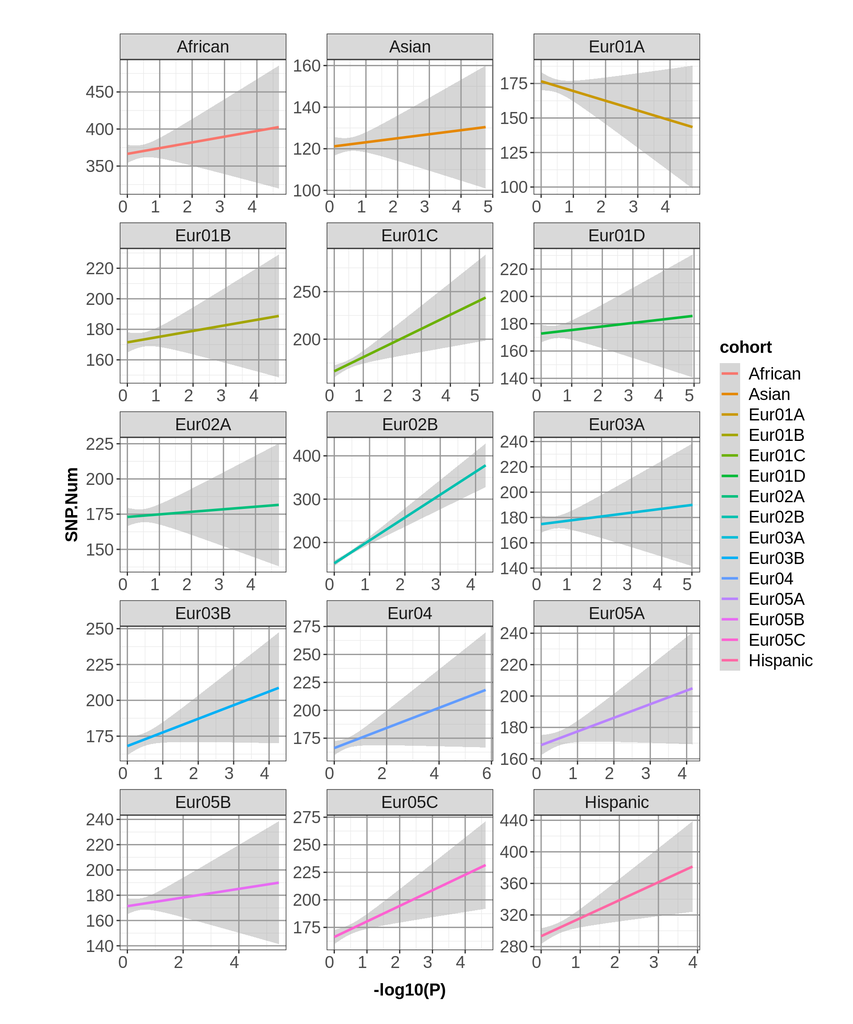

```r
> assoc.long %>% left_join(snp.num.long) %>% # remove missing data points
+ filter(!is.na(P)) %>% group_by(cohort) %>% ggplot(aes(x = -log10(P), y = SNP.Num,
+     color = cohort)) + geom_smooth(method = "lm", se = TRUE) + facet_wrap(~cohort,
+     scales = "free", ncol = 3) + my_ggplotTheme + ggsave(paste0(OUTFOLDER, SCRIPT,
+     ".supp.correlation_numberSNPs_and_PValue.", DATE, ".pdf"), device = "pdf", dpi = 300,
+     height = 10)
```

## 3.2 Meta-Analysis

For overall Meta-Analysis remove genes with more than half of cohorts missing (Number_missingPvalues>8) or for European only Meta-Analysis more than half of European cohorts missing (Number_missingPvalues>6)

```r
> meta.qc = meta %>% mutate(QC_flag.missing_all = ifelse(Number_missingPvalues > 8,
+     "YES", "NO"), QC_flag.missing_european = ifelse(Number_missingPvalues > 6, "YES",
+     "NO"))
```

### 3.2.1 How many and which genes removed?

#### 3.2.1.1 Meta-Analysis all (YES = ‘more than half cohorts with missing result’ | NO = ‘all good’)

```r
> meta.qc %>% count(QC_flag.missing_all)
```

```
# A tibble: 2 x 2
  QC_flag.missing_all     n
  <chr>               <int>
1 NO                  17960
2 YES                   701
```

#### 3.2.1.2 Meta-Analysis European (YES = ‘more than half cohorts with missing result’ | NO = ‘all good’)

```r
> meta.qc %>% count(QC_flag.missing_european)
```

```
# A tibble: 2 x 2
  QC_flag.missing_european     n
  <chr>                    <int>
1 NO                       17951
2 YES                        710
```

# 4 Top Hits

## 4.1 Meta-Analysis all (FDR corrected Meta-Analysis PValue < 0.05)

```r
> hits.meta.all = meta.qc %>% filter(QC_flag.missing_all == "NO") %>% filter(StoufferMetaP_FDR <
+     0.05) %>% arrange(StoufferMetaP_FDR) %>% mutate(Hit = "meta.all.fdr.p")
```

```r
> hits.meta.all %>% select(-StoufferMetaEuropeanP, -StoufferMetaEuropeanP_FDR) %>%
+     myDT()
```

| CurrentGene | StoufferMetaP | StoufferMetaP_FDR | Number_missingPvalues | QC_flag.missing_all | QC_flag.missing_european | Hit |
| --- | --- | --- | --- | --- | --- | --- |
| MAP3K1 | 2.27682526066034e-17 | 4.22373854105099e-13 | 0 | NO | NO | meta.all.fdr.p |
| FAM72B | 8.26369280477545e-14 | 7.66498826106947e-10 | 1 | NO | NO | meta.all.fdr.p |
| SRGAP2C | 6.83676707894077e-13 | 4.22762886938101e-09 | 1 | NO | NO | meta.all.fdr.p |
| FGFR2 | 6.51569092076744e-08 | 0.000302181455677892 | 1 | NO | NO | meta.all.fdr.p |
| TNNT3 | 1.4838868835771e-06 | 0.00471681863347325 | 1 | NO | NO | meta.all.fdr.p |
| LSP1 | 1.52557338153412e-06 | 0.00471681863347325 | 1 | NO | NO | meta.all.fdr.p |
| FMNL3 | 1.23696388830354e-05 | 0.0269170269896465 | 0 | NO | NO | meta.all.fdr.p |
| ESR1 | 1.3058770034328e-05 | 0.0269170269896465 | 0 | NO | NO | meta.all.fdr.p |
| MIER3 | 1.04177627096939e-05 | 0.0269170269896465 | 0 | NO | NO | meta.all.fdr.p |

## 4.2 Meta-Analysis european (FDR corrected Meta-Analysis PValue < 0.05)

```r
> hits.meta.euro = meta.qc %>% filter(QC_flag.missing_european == "NO") %>% filter(StoufferMetaEuropeanP_FDR <
+     0.05) %>% arrange(StoufferMetaEuropeanP_FDR) %>% mutate(Hit = "meta.european.fdr.p")
```

```r
> hits.meta.euro %>% select(-StoufferMetaP, -StoufferMetaP_FDR) %>% myDT()
```

| CurrentGene | StoufferMetaEuropeanP | StoufferMetaEuropeanP_FDR | Number_missingPvalues | QC_flag.missing_all | QC_flag.missing_european | Hit |
| --- | --- | --- | --- | --- | --- | --- |
| MAP3K1 | 4.60571328628407e-22 | 8.27784848943836e-18 | 0 | NO | NO | meta.european.fdr.p |
| FAM72B | 1.32379560366593e-15 | 1.18962891923439e-11 | 1 | NO | NO | meta.european.fdr.p |
| SRGAP2C | 1.01336805637179e-14 | 6.07108802572337e-11 | 1 | NO | NO | meta.european.fdr.p |
| TNNT3 | 6.16506444457769e-08 | 0.000277011758155987 | 1 | NO | NO | meta.european.fdr.p |
| LSP1 | 1.30751946504504e-07 | 0.000470000946905091 | 1 | NO | NO | meta.european.fdr.p |
| FGFR2 | 9.48105562022919e-07 | 0.00284005021103965 | 1 | NO | NO | meta.european.fdr.p |
| MIER3 | 2.81255135987054e-06 | 0.00722142651299331 | 0 | NO | NO | meta.european.fdr.p |
| FMNL3 | 6.11484007301058e-06 | 0.0137377525790274 | 0 | NO | NO | meta.european.fdr.p |
| LYPD5 | 1.38540479219186e-05 | 0.020316224356992 | 1 | NO | NO | meta.european.fdr.p |
| KCNN4 | 1.12141079860754e-05 | 0.020316224356992 | 1 | NO | NO | meta.european.fdr.p |

[output cut: 4 more lines]

## 4.3 Asian ancestry

### 4.3.1 FDR corrected PValue < 0.05 -> NONE

```r
> assoc.long %>% filter(cohort == "Asian") %>% filter(P_FDR < 0.05)
```

```
# A tibble: 0 x 5
# Groups:   cohort [0]
# … with 5 variables: CurrentGene <fct>, cohort <chr>, metric <chr>, P <dbl>,
#   P_FDR <dbl>
```

### 4.3.2 uncorrected PValue < 1e-4

```r
> hits.asian = assoc.long %>% filter(cohort == "Asian") %>% filter(P < 1e-04)
```

## 4.4 African ancestry

### 4.4.1 FDR corrected PValue < 0.05 -> NONE

```r
> assoc.long %>% filter(cohort == "African") %>% filter(P_FDR < 0.05)
```

```
# A tibble: 0 x 5
# Groups:   cohort [0]
# … with 5 variables: CurrentGene <fct>, cohort <chr>, metric <chr>, P <dbl>,
#   P_FDR <dbl>
```

### 4.4.2 uncorrected PValue < 1e-4

```r
> hits.african = assoc.long %>% filter(cohort == "African") %>% filter(P < 1e-04)
```

## 4.5 Hispanic ancestry

### 4.5.1 FDR corrected PValue < 0.05 -> NONE

```r
> assoc.long %>% filter(cohort == "Hispanic") %>% filter(P_FDR < 0.05)
```

```
# A tibble: 0 x 5
# Groups:   cohort [0]
# … with 5 variables: CurrentGene <fct>, cohort <chr>, metric <chr>, P <dbl>,
#   P_FDR <dbl>
```

### 4.5.2 uncorrected PValue < 1e-4 , also NONE

```r
> hits.hispanic = assoc.long %>% filter(cohort == "Hispanic") %>% filter(P < 1e-04)
```

## 4.6 Combine hit results

### 4.6.1 Format inputs

```r
> hits.meta.all.format = hits.meta.all %>% mutate(cohort = "meta.all") %>% select(cohort,
+     CurrentGene, Hit, P = StoufferMetaP_FDR)
>
> hits.meta.euro.format = hits.meta.euro %>% mutate(cohort = "meta.euro") %>% select(cohort,
+     CurrentGene, Hit, P = StoufferMetaEuropeanP_FDR)
>
> hits.asian.format = hits.asian %>% mutate(Hit = "single.asian.uncorrP.1e-4") %>%
+     select(CurrentGene, Hit, P)
>
> hits.african.format = hits.african %>% mutate(Hit = "single.african.uncorrP.1e-4") %>%
+     select(CurrentGene, Hit, P)
```

### 4.6.2 Combine

```r
> hit.list = list(hits.meta.all.format, hits.meta.euro.format, hits.asian.format, hits.african.format)
> Hits = data.table::rbindlist(hit.list)
```

## 4.7 The Hit Genes

```r
> Hits %>% count(CurrentGene) %>% arrange(-n)
```

```
# A tibble: 24 x 2
   CurrentGene     n
   <fct>       <int>
 1 FAM72B          2
 2 FGFR2           2
 3 FMNL3           2
 4 LSP1            2
 5 MAP3K1          2
 6 MIER3           2
 7 SRGAP2C         2
 8 TNNT3           2
 9 ANKRD28         1
10 BTN2A1          1
# … with 14 more rows
```

## 4.8 Save

```r
> Hits %>% write_csv(paste0(OUTFOLDER, SCRIPT, ".all_hits.", DATE, ".csv"))
```

# 5 Overlap between cohorts

## 5.1 extend hit data with Pvalues from all cohort and respective ranks

### 5.1.1 format single assoc results

```r
> hit_genes = unique(Hits$CurrentGene)
>
> assoc.hits = assoc.long %>% group_by(cohort) %>% mutate(P_rank = frank(P, na.last = "keep")) %>%
+     filter(CurrentGene %in% hit_genes) %>% select(CurrentGene, cohort, metric, P,
+     P_rank)
```

### 5.1.2 format meta analysis results

```r
> meta.hits = meta.qc %>% filter(QC_flag.missing_all == "NO" & QC_flag.missing_european ==
+     "NO") %>% select(CurrentGene, StoufferMetaP_FDR, StoufferMetaEuropeanP_FDR) %>%
+     pivot_longer(col = -CurrentGene, names_to = "metric", values_to = "P") %>% mutate(cohort = ifelse(metric ==
+     "StoufferMetaP_FDR", "meta.all", "meta.euro")) %>% group_by(cohort) %>% mutate(P_rank = frank(P,
+     na.last = "keep")) %>% filter(CurrentGene %in% hit_genes) %>% select(CurrentGene,
+     cohort, metric, P, P_rank)
```

### 5.1.3 combine all

```r
> hits.extended = assoc.hits %>% rbind(meta.hits) %>% left_join(Hits[, -"P"], by = c("CurrentGene",
+     "cohort")) %>% mutate(is_a_hit = ifelse(is.na(Hit), "NO", "YES"))
```

### 5.1.4 add number of significant analyses and median rank

```r
> hits.gene.summary = hits.extended %>% group_by(CurrentGene) %>% summarise(MedianRank = median(P_rank,
+     na.rm = T), NumberHitAnalyses = sum(!is.na(Hit)))
```

```r
> hits.gene.summary %>% arrange(MedianRank) %>% myDT
```

| CurrentGene | MedianRank | NumberHitAnalyses |
| --- | --- | --- |
| MAP3K1 | 77 | 2 |
| FAM72B | 159.5 | 2 |
| SRGAP2C | 164 | 2 |
| ESR1 | 1033 | 1 |
| FGFR2 | 1102 | 2 |
| TNNT3 | 1245.5 | 2 |
| FMNL3 | 1434 | 2 |
| LSP1 | 1545.5 | 2 |
| ZNF404 | 1735.5 | 1 |
| LYPD5 | 1806.5 | 1 |

[output cut: 14 more lines]

# 6 Not all hits are independend!

## 6.1 add loci info (created based on locuszoom plots and overlap of regions)

region data for loci based on genocodeV25 files in mummy folder. for multi-gene loci minimum+maximum used to define region of all present genes.

```r
> loci = data.frame(
+   CurrentGene = c("FAM72B", "SRGAP2C",       #2
+                   "COLQ", "ANKRD28",         #4
+                   "CBLB", "RP11-231C18.3",   #6
+                   "FAM175A", "MAP3K1",       #8
+                   "MIER3", "BTN2A1",         #10
+                   "ESR1", "RBM18",           #12
+                   "MRRF", "FGFR2",           #14
+                   "FAM53B", "LSP1",          #16
+                   "TNNT3", "TRIM49",         #18
+                   "FMNL3", "KCNN4",          #20
+                   "LYPD5", "ZNF404",         #22
+                   "SIGLECL1", "IGLON5"),     #24
+   Loci = c("Loci01", "Loci02",               #2
+            "Loci03","Loci03",                #4
+            "Loci04","Loci05",                #6
+            "Loci06","Loci07",                #8
+            "Loci07","Loci08",                #10
+            "Loci09","Loci10",                #12
+            "Loci10","Loci11",                #14
+            "Loci12","Loci13",                #16
+            "Loci13","Loci14",                #18
+            "Loci15","Loci16",                #20
+            "Loci16","Loci16",                #22
+            "Loci17","Loci17"),               #24
+   Regions_hg38 = c("chr1:121,167,646-121,185,539", #FAM52B
+                    "chr1:121,184,810-121,392,822", #SRGAP2C                     #2
+                    "chr3:15,450,133-15,859,771",   #COLQ + ANKRD28
+                    "chr3:15,450,133-15,859,771",   #COLQ + ANKRD28              #4
+                    "chr3:105,655,461-105,869,552",  #CBLB
+                    "chr4:53,377,839-54,295,272", #RP11-231C18.3                     #6
+                    "chr4:83,459,517-83,523,348",  #FAM175A
+                    "chr5:56,815,574-56,971,675",  #MAP3K1 +MIER3                    #8
+                    "chr5:56,815,574-56,971,675",  #MAP3K1 +MIER3
+                    "chr6:26,457,904-26,476,621",  #BTN2A1                           #10
+                    "chr6:151,656,691-152,129,619",  #ESR1
+                    "chr9:122,237,624-122,331,343", #RBM18+MRRF                      #12
+                    "chr9:122,237,624-122,331,343", #RBM18+MRRF
+                    "chr10:121,478,334-121,598,458", #FGFR2                          #14
+                    "chr10:124,619,292-124,744,269", #FAM53B
+                    "chr11:1,852,970-1,938,706", #LSP1+TNNT3                         #16
+                    "chr11:1,852,970-1,938,706", #LSP1+TNNT3
+                    "chr11:49,027,501-49,038,451", #TRIM49                           #18
+                    "chr12:49,636,499-49,708,165", #FMNL3
+                    "chr19:43,766,533-43,901,385",  #KCNN4+LYPD5+ZNF404              #20
+                    "chr19:43,766,533-43,901,385",  #KCNN4+LYPD5+ZNF404
+                    "chr19:43,766,533-43,901,385",  #KCNN4+LYPD5+ZNF404              #22
+                    "chr19:51,246,348-51,269,330",  #SIGLECL1+IGLON5
+                    "chr19:51,246,348-51,269,330"))  #SIGLECL1+IGLON5                 #24
```

# 7 Add overlap with previous BCAC GWAS results

## 7.1 Did BCAC also report our findings?

### 7.1.1 Creating Locuszoom plots

1. go to biomart b37 and retrieve positions for all hit genes
- results in file: `data/output/S03.hg37_position_hit_genes.2021-01-28.txt`
- manually added entry for RP11-231C18.3 from file `/scripts/B_mummy/mummy_genotype/gencode_genes_V25_GRCh37.tsv.gz`
2. create bed file of coding areas `awk '{OFS="\t"; print $5, $3, $4, $6, $1}' S03.hg37_position_hit_genes..2021-01-28txt >S03.hg37_position_hit_genes..2021-01-28bed`
3. add window range of 100kb to start and end of gene in new bed file

## 7.2 load in locuszoom data

```r
> bcac_ref = read.csv(paste0(OUTFOLDER, "S03.locuszoom_regions.2021-01-28.csv"))
```

### 7.2.1 reformat locus data

```r
> bcac_ref.format = bcac_ref %>% mutate(cohort = "BCAC_ref", metric = "PValue", P = 10^(-BCAC_study_max_neg_log_P),
+     P_rank = NA_real_, Hit = NA_character_, is_a_hit = as.character(BCAC_study_hit)) %>%
+     select(CurrentGene = "GENE", cohort, metric, P, P_rank, Hit, is_a_hit)
```

# 8 European hits vs BCAC known

## 8.1 make plot data

```r
> eurohit_plot_data.tmp = hits.extended %>% filter(cohort == "meta.euro") %>% filter(is_a_hit ==
+     "YES")
>
> eurohit_plot_data = eurohit_plot_data.tmp %>% bind_rows(bcac_ref.format[bcac_ref.format$CurrentGene %in%
+     eurohit_plot_data.tmp$CurrentGene, ]) %>% left_join(loci, "CurrentGene") %>%
+     mutate(cohort_fct = recode(cohort, meta.euro = "Euopean\nMeta-Analysis", BCAC_ref = "BCAC\nreplication")) %>%
+     mutate(Regions_hg38_fct = factor(Regions_hg38, levels = c("chr1:121,167,646-121,185,539",
+         "chr1:121,184,810-121,392,822", "chr3:15,450,133-15,859,771", "chr3:105,655,461-105,869,552",
+         "chr4:53,377,839-54,295,272", "chr4:83,459,517-83,523,348", "chr5:56,815,574-56,971,675",
+         "chr6:26,457,904-26,476,621", "chr6:151,656,691-152,129,619", "chr9:122,237,624-122,331,343",
+         "chr10:121,478,334-121,598,458", "chr10:124,619,292-124,744,269", "chr11:1,852,970-1,938,706",
+         "chr11:49,027,501-49,038,451", "chr12:49,636,499-49,708,165", "chr19:43,766,533-43,901,385",
+         "chr19:51,246,348-51,269,330")))
```

## 8.2 qualitive plot (hit vs no-hit)

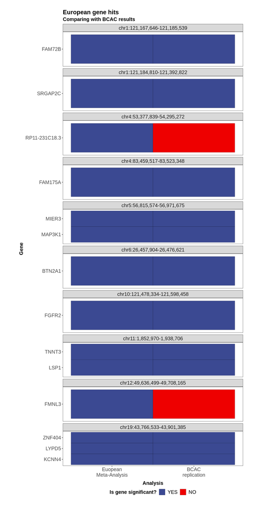

```r
> eurohit_plot_data %>% ggplot(aes(y = reorder(CurrentGene, Loci), x = fct_relevel(cohort_fct,
+     "Euopean\nMeta-Analysis"), fill = fct_relevel(is_a_hit, "YES"))) + geom_tile(color = "black") +
+     my_ggplotTheme + scale_fill_aaas() + facet_wrap(~Regions_hg38_fct, scales = "free_y",
+     ncol = 1, shrink = F) + labs(title = "European gene hits", subtitle = "Comparing with BCAC results",
+     x = "Analysis", y = "Gene", fill = "Is gene significant?") + theme(panel.grid.major = element_blank()) +
+     ggthemr::legend_bottom() + ggsave(paste0(OUTFOLDER, SCRIPT, ".EURO.hits_overlap.qual.LOCI.plus_BCAC_ref.",
+     DATE, ".pdf"), dpi = 300, device = "pdf", height = 12, width = 6)
```

## 8.3 quantiative plot (color by pvalue)

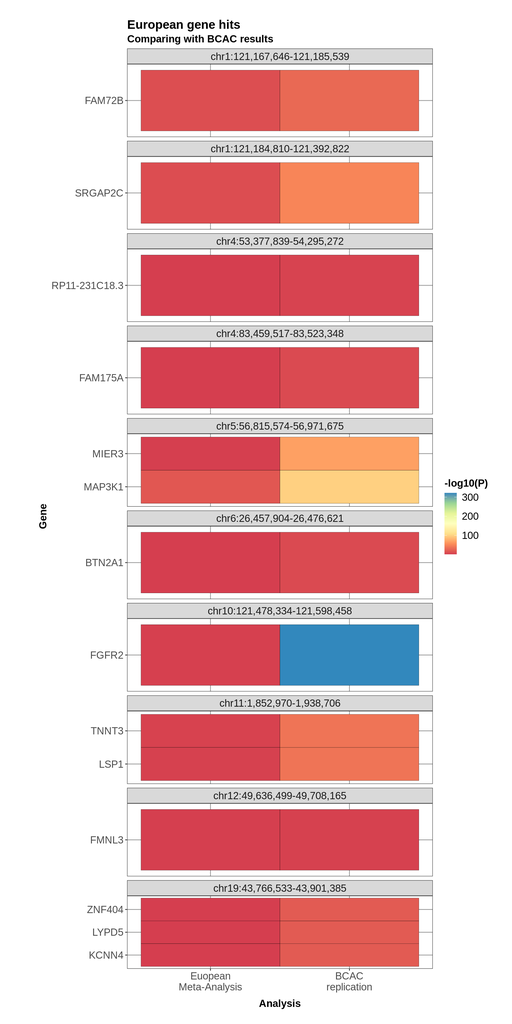

```r
> eurohit_plot_data %>% ggplot(aes(y = reorder(CurrentGene, Loci), x = fct_relevel(cohort_fct,
+     "Euopean\nMeta-Analysis"), fill = -log10(P))) + geom_tile(color = "black") +
+     my_ggplotTheme + scale_fill_distiller(palette = "Spectral", direction = 1) +
+     facet_wrap(~Regions_hg38_fct, scales = "free_y", ncol = 1, shrink = F) + labs(title = "European gene hits",
+     subtitle = "Comparing with BCAC results", x = "Analysis", y = "Gene", fill = "-log10(P)")  # +
```

```r
> ggsave(paste0(OUTFOLDER, SCRIPT, ".EURO.hits_overlap.quanti.LOCI.plus_BCAC_ref.",
+     DATE, ".pdf"), dpi = 300, device = "pdf", height = 20, width = 8)
```